# Distribuciones de probabilidad

ASR

25/5/2021

## Introducción de distribuciones de probabilidad

- Experimento aleatorio (ej. Tirar la moneda)
- Suceso elemental: Sacar la Cara (C) o la Cruz (+)
- Espacio muestral: $\Omega$ {C,+}
- Suceso: Subconjunto
- Suceso total: Todo el espacio muestral.
- Suceso vacío o imposible.

## Variables aleatorias (v.a.)

El total es $\Omega$. La variable aleatoria es $X(\omega)$ y Dx el dominio que son los valores que puede tomar.

Función de distribución de la v.a. $F(x)=p(X<=x)$ - Como probabilidad acumulada del valor x. $p(x<=a) = F(a)$ $p(x<a) = F(a^-)$ $p(x=a) = F(a) - F(a^-)$ $p(a<=x<=a) = F(b) - F(a^-)$

Quantiles se aplica con probabilidades (0.25, 0.5 y 0.75)

### Variables aleatorias discretas

Funcion de densidad: $f(x) = p(X=x)$ Esperanza de una variable aleatoria discreta: Producto del elemento o transformacion del mismo por su probabilidad.
$$E(X) = \sum_{x€D_x}x\cdot f(x)$$
Tambien aplica:
$$E(g(x)) = \sum_{x€D_x}g(x)\cdot f(x)$$

Varianza de una v.a discreta: Como se alejan los valores de x de la media.
$$Var(X) = E((X-E(X))^2)= E(X^2)-(E(X))^2$$
Tambian aplica:
$$Var(g(X)) = E((g(X)-E(g(X)))^2)= E(g(X)^2)-(E(g(X)))^2$$
Desviación típica: $\sigma(x)=\sqrt{Var(X)}$ $\sigma(g(x))=\sqrt{Var(g(X))}$

## Sesgo (Skewness) en una distribución de probabilidad

Campanas de distribución normal pero tumbadas a izquierda o derecha. Sesgo a izquierda o a derecha. A veces se define como (media - mediana) / sigma Es ver si mediana, media y moda están próximas o no, en caso de que no hay un sesgo claro.

## Distribuciones de probabilidad

Funciones en R: dva(x,…): Función de densidad o probabilidad pva(x,…): Función de distribución qva(p,…): Cuantil p-esimo rva(n,…): Generador de n observaciones

Funciones en python: pmf(k,…) o pdf(x,…): Funciones de probabilidad o densidad cdf(x,…): Función de distribución ppf(p,…): Cuantil p-esimo rvs(size,…): Generador de size observaciones

### Distrbución de Bernoulli

variable aleatoria con 0(fracaso), 1(exito) donde p sería la probabilidad de 1 y (1-p) la probabilidad del 0 fracaso.

$$f(k) = p^k(1-p)^{1-k}, k\in\{0,1\}$$
Con q = 1-p:
$$E(X)=p$$
$$Var(X)=pq$$
Probamos con la función: Sea $X=Be(p=0.7)$, la distribución que modela la probabilidad de obtener el resultado sería:

```r
library(Rlab)
dbern(0,prob=0.7)
```

```
## [1] 0.3
```

```r
dbern(1,prob=0.7)
```

```
## [1] 0.7
```

```r
pbern(0,prob=0.7)
```

```
## [1] 0.3
```

```r
pbern(1,prob=0.7)
```

```
## [1] 1
```

```r
qbern(0.5,prob=0.7)
```

```
## [1] 1
```

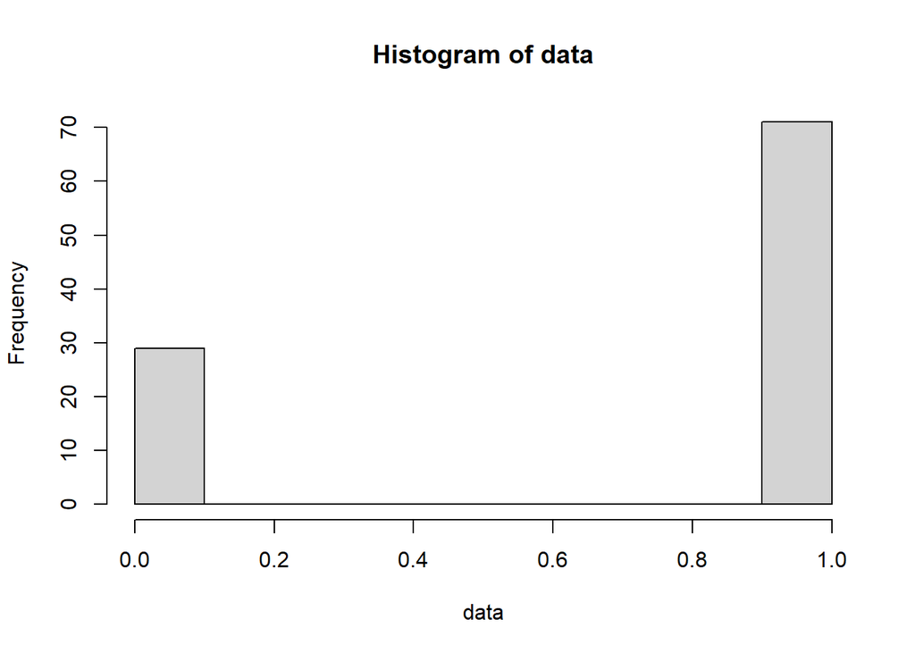

```r
rbern(100,prob=0.7) -> data
hist(data)
```

```r
library(reticulate)
```

```r
py_install("scipy")
py_install("matplotlib")
```

### En Python

```python
from scipy.stats import bernoulli
import matplotlib.pyplot as plt
p=0.7
mean,var,skew,kurt = bernoulli.stats(p,moments='mvsk')
print("Media %f"%mean)
```

```
## Media 0.700000
```

```python
print("Var %f"%var)
```

```
## Var 0.210000
```

```python
print("Sesgo %f"%skew)
```

```
## Sesgo -0.872872
```

```python
print("Kurt %f"%kurt)
```

```
## Kurt -1.238095
```

```python
fix,ax = plt.subplots(1,1)
x = bernoulli.rvs(p,size=1000)
ax.hist(x)
```

```
## (array([292.,   0.,   0.,   0.,   0.,   0.,   0.,   0.,   0., 708.]), array([0. , 0.1, 0.2, 0.3, 0.4, 0.5, 0.6, 0.7, 0.8, 0.9, 1. ]), <a list of 10 Patch objects>)
```

```python
plt.show()
```

[output not shown]

## Distribución Binomial

Distribución de un número de existos de un experimento con dos valores posibles. En n experimentos puedes tener 0 éxitos hasta n. Si n=1 sería la de Bernoulli Esperanza(X) = np Var(X) = npq

En R se usa Rlab: dbinom , pbinom, qbinom, rbinom Python: scipy.stats.binomial > pmf,cdf, ppf, rvs

Sea $X=V(n=30,p=0.6)$

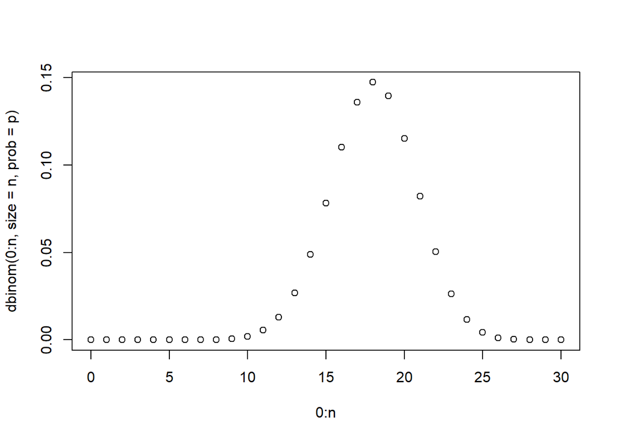

```r
library(Rlab)
n=30
p=0.6
plot(0:n,dbinom(0:n,size=n,prob=p))
```

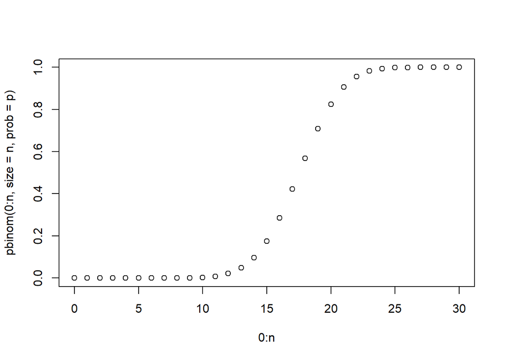

```r
plot(0:n,pbinom(0:n,size=n,prob=p))
```

```r
qbinom(0.5,n,p)
```

```
## [1] 18
```

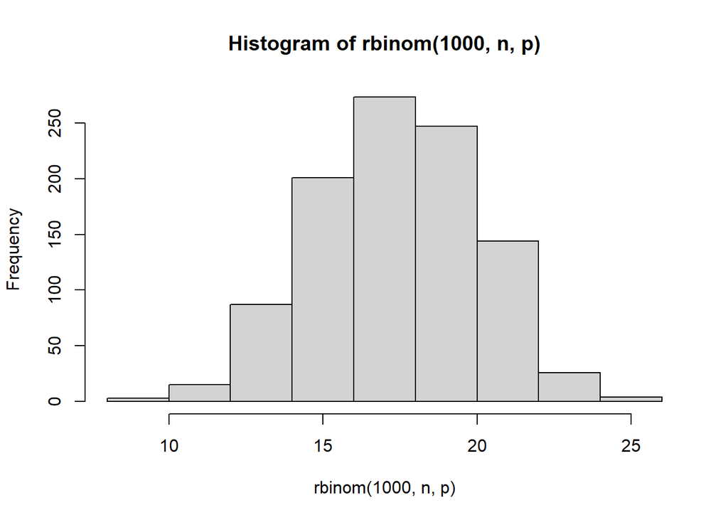

```r
hist(rbinom(1000,n,p))
```

### En python

```python
from scipy.stats import binom
import matplotlib.pyplot as plt
import numpy as np

n=7
p=0.4

mean,var,skew,kurt = binom.stats(n,p,moments='mvsk')
print("Media %f"%mean)
```

```
## Media 2.800000
```

```python
print("Var %f"%var)
```

```
## Var 1.680000
```

```python
print("Sesgo %f"%skew)
```

```
## Sesgo 0.154303
```

```python
print("Kurt %f"%kurt)
```

```
## Kurt -0.261905
```

```python
fix,ax = plt.subplots(1,1)

x = np.arange(0,n+1)
ax.plot(x,binom.pmf(x,n,p),'bo',ms=8,label="Función de densidad de B(7,0.4)")
ax.vlines(x,0,binom.pmf(x,n,p),colors='b',lw=4,alpha=0.5)
rv=binom(n,p)
ax.vlines(x,0,rv.pmf(x),colors='k',linestyles='--',lw=1,label="Distribución teórica")
ax.legend(loc='best',frameon=False)
plt.show()
```

[output not shown]

## Distribución Geométrica

X variable aleatoria que mide numero de repeticiones hasta el primer éxito. A veces se cuentan los fracasos y a veces los intentos. X = Ge(p)

$f(k)=(1-p)^kp$ Si empieza en 0 $f(k)=(1-p)^{k-1}p$ Si empieza en 1 $E(X)=\frac{1-p}{p}$ empezando en 0 y $\frac{1}{p}$ si empieza en 1.

Sea $X=Geom(p=0.1)$:

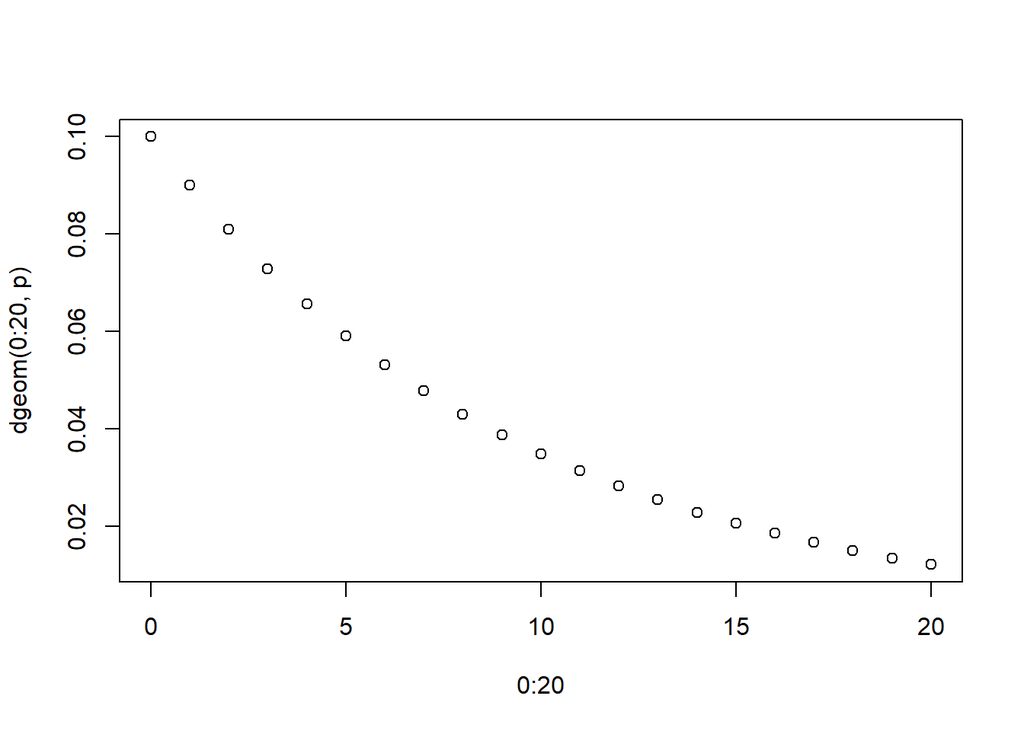

```r
library(Rlab)
p=0.1
plot(0:20,dgeom(0:20,p))
```

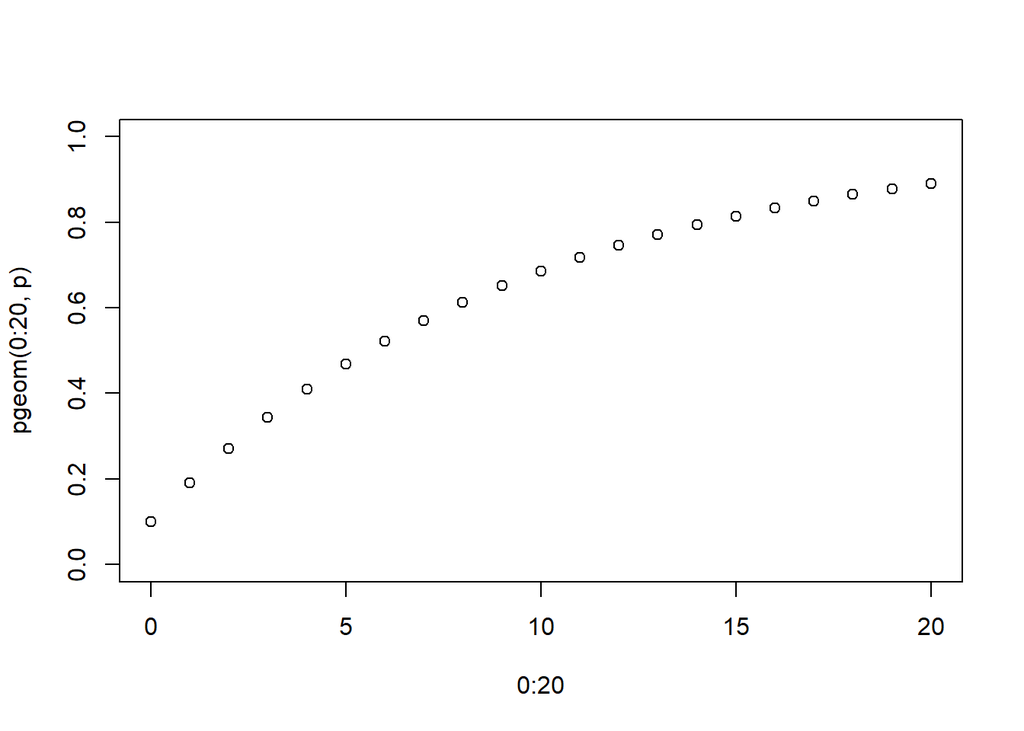

```r
plot(0:20,pgeom(0:20,p),ylim=c(0,1))
```

```r
qgeom(0.5,p)
```

```
## [1] 6
```

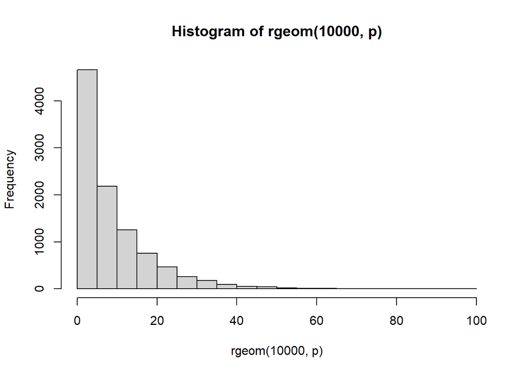

```r
hist(rgeom(10000,p))
```

### En Python:

```python
from scipy.stats import geom
import matplotlib.pyplot as plt
import numpy as np

fig,ax = plt.subplots(1,1)
p=0.3

mean,var,skew,kurt = geom.stats(p,moments='mvsk')
print("Media %f"%mean)
```

```
## Media 3.333333
```

```python
print("Var %f"%var)
```

```
## Var 7.777778
```

```python
print("Sesgo %f"%skew)
```

```
## Sesgo 2.031889
```

```python
print("Kurt %f"%kurt)
```

```
## Kurt 6.128571
```

```python
x = np.arange(geom.ppf(0.01,p),geom.ppf(0.99,p))
ax.plot(x,geom.ppf(x,p),'bo',ms=8,label="Dist. Geom(0.3)")
ax.vlines(x,0,geom.pmf(x,p),colors='b',lw=4,alpha=0.5)
rv = geom(p)
ax.vlines(x,0,rv.pmf(x),colors='k',linestyles='--',lw=1,label="FROZEN PMF")
ax.legend(loc='best')
plt.show()
```

[output not shown]

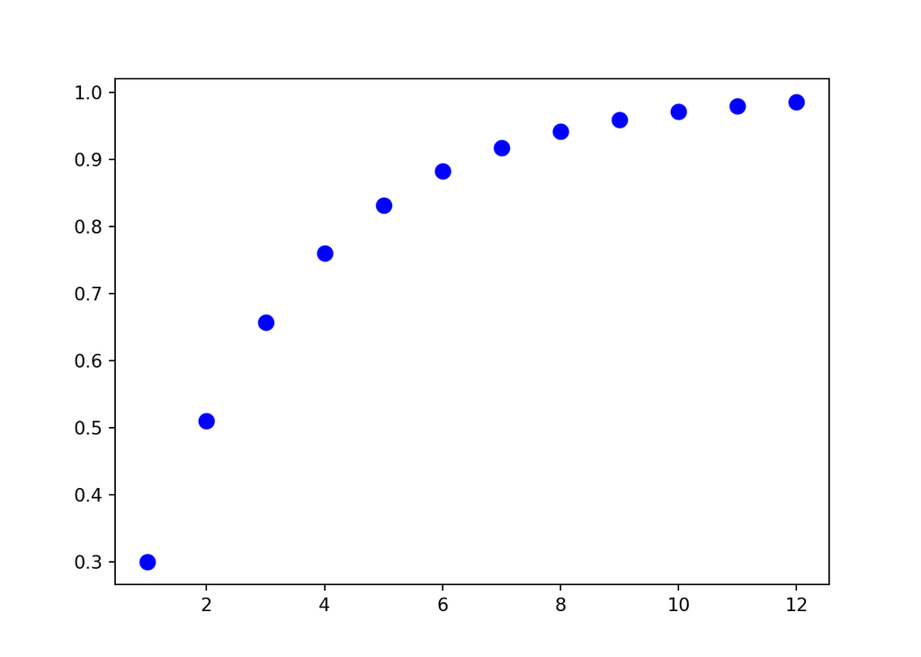

```python
fig,ax = plt.subplots(1,1)
prob = geom.cdf(x,p)
ax.plot(x,prob,'bo',ms=8,label="Función de distribución acumulada")
plt.show()
```

```python
fig,ax = plt.subplots(1,1)
r = geom.rvs(p,size=10000)
plt.hist(r)
```

```
## (array([6.588e+03, 2.225e+03, 7.810e+02, 2.610e+02, 9.700e+01, 3.500e+01,
##        6.000e+00, 5.000e+00, 0.000e+00, 2.000e+00]), array([ 1.,  4.,  7., 10., 13., 16., 19., 22., 25., 28., 31.]), <a list of 10 Patch objects>)
```

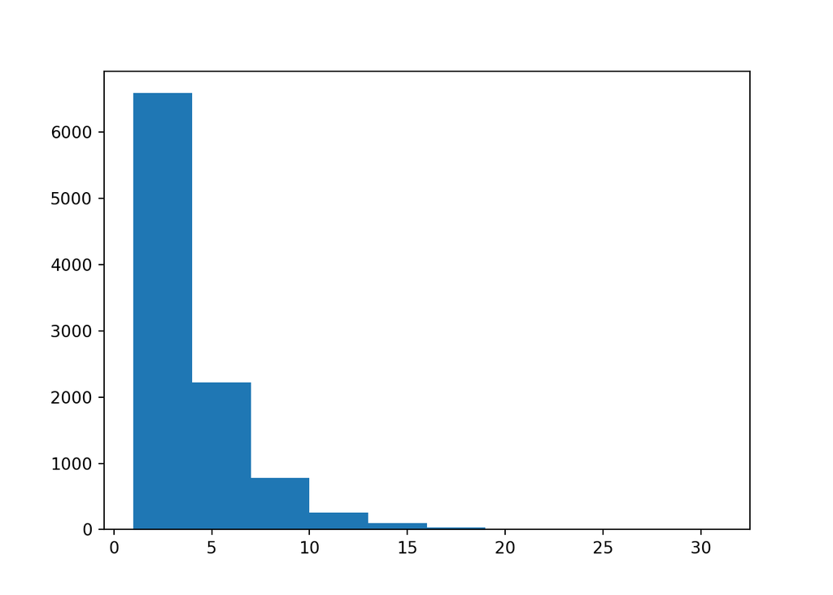

```python
plt.show()
```

## Distribución Hipergeométrica

Modela la extracción de objetos de un conjunto donde hay N objetos de tipo 1 y M objetos de tipo 2. Se extraen n objetos y se mide el nº de objetos de tipo 1 (tipo A)

Tenemos 20 animales y 7 son perros. Medir prob de encontrar un num de perros si elegimos x animales al azar.

```r
library(Rlab)
M=7
N=13
k=12
dhyper(x=0:12,m=M,n=N,k=k)
```

```
##  [1] 0.0001031992 0.0043343653 0.0476780186 0.1986584107 0.3575851393
##  [6] 0.2860681115 0.0953560372 0.0102167183 0.0000000000 0.0000000000
## [11] 0.0000000000 0.0000000000 0.0000000000
```

```r
phyper(q=0:12,m=M,n=N,k=k)
```

```
##  [1] 0.0001031992 0.0044375645 0.0521155831 0.2507739938 0.6083591331
##  [6] 0.8944272446 0.9897832817 1.0000000000 1.0000000000 1.0000000000
## [11] 1.0000000000 1.0000000000 1.0000000000
```

```r
qhyper(p=0.5,m=M,n=N,k=k)
```

```
## [1] 4
```

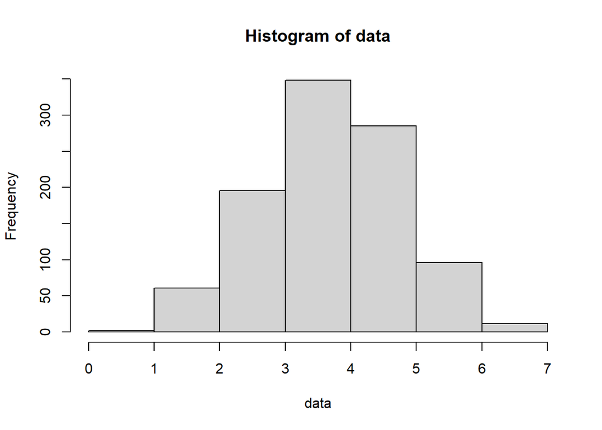

```r
rhyper(nn=1000,m=M,n=N,k=k) -> data
hist(data,breaks=8)
```

### En Python

```python
from scipy.stats import hypergeom
import matplotlib.pyplot as plt
import numpy as np

[M,n,N] = [20,7,12]



rv = hypergeom(M,n,N)
x = np.arange(0,n+1)
y = rv.pmf(x)

mean,var,skew,kurt = rv.stats(moments='mvsk')
print("Media %f"%mean)
```

```
## Media 4.200000
```

```python
print("Var %f"%var)
```

```
## Var 1.149474
```

```python
print("Sesgo %f"%skew)
```

```
## Sesgo -0.062181
```

```python
print("Kurt %f"%kurt)
```

```
## Kurt -0.152661
```

```python
fig = plt.figure()
ax=fig.add_subplot(111)

ax.plot(x,y,'bo')
ax.vlines(x,0,y,colors='b',lw=4,alpha=0.5)
ax.set_xlabel("Nº de perros entre los 12 elegidos al azar")
ax.set_ylabel("Dist. probabilidad de H(13,7,12)")
plt.show()
```

[output not shown]

## Distribución de Poisson

Nº de eventos en un cierto intervalo de tiempo.
$$f(k)=\frac{e^{-\lambda \lambda^k}}{k!}$$
$E(X)=\lambda$ $Var(X)=\lambda$

X modelo errores ortograficos por página tiene una valor esperado de $\lambda=5$

```r
l=5
dpois(x=0:10,lambda=l)
```

```
##  [1] 0.006737947 0.033689735 0.084224337 0.140373896 0.175467370 0.175467370
##  [7] 0.146222808 0.104444863 0.065278039 0.036265577 0.018132789
```

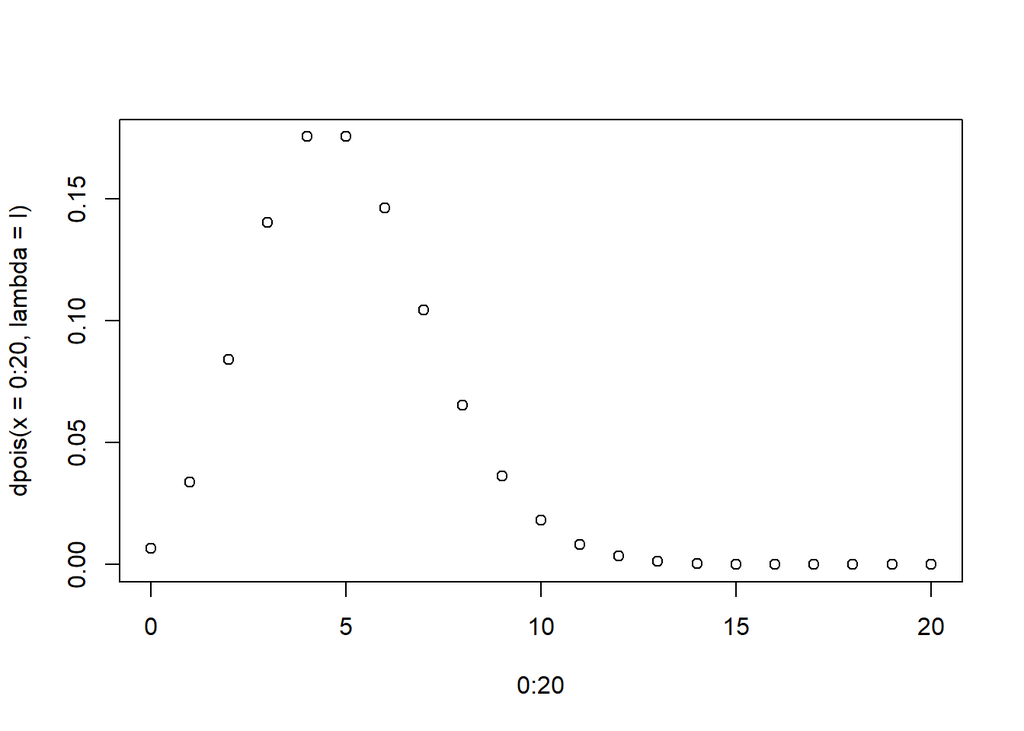

```r
plot(0:20,dpois(x=0:20,lambda=l))
```

```r
ppois(0:20,l)
```

```
##  [1] 0.006737947 0.040427682 0.124652019 0.265025915 0.440493285 0.615960655
##  [7] 0.762183463 0.866628326 0.931906365 0.968171943 0.986304731 0.994546908
## [13] 0.997981148 0.999302010 0.999773746 0.999930992 0.999980131 0.999994584
## [19] 0.999998598 0.999999655 0.999999919
```

```r
qpois(0.5,5)
```

```
## [1] 5
```

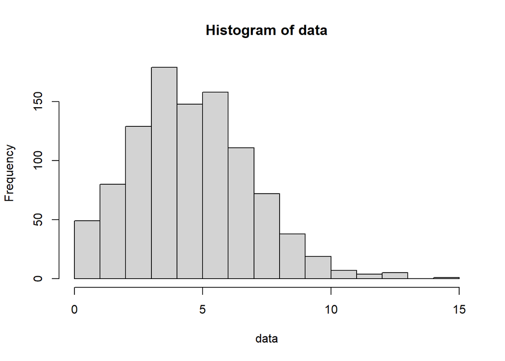

```r
rpois(1000,lambda=l) -> data
hist(data)
```

### En Python:

```python
from scipy.stats import poisson

fig,ax = plt.subplots(1,1)
mu = 0.8

mean,var,skew,kurt = poisson.stats(mu,moments='mvsk')
print("Media %f"%mean)
```

```
## Media 0.800000
```

```python
print("Var %f"%var)
```

```
## Var 0.800000
```

```python
print("Sesgo %f"%skew)
```

```
## Sesgo 1.118034
```

```python
print("Kurt %f"%kurt)
```

```
## Kurt 1.250000
```

```python
x = np.arange(0,5)
ax.plot(x,poisson.pmf(x,mu),'bo',ms=8,label="Dist. Poisson(0.8)")
ax.vlines(x,0,poisson.pmf(x,mu),colors='b',lw=4,alpha=0.5)
ax.legend(loc='best',frameon=False)
plt.show()
```

[output not shown]

## Distribución Binomial Negativa

Numero de repeticiones de (exito,fracaso) hasta alcanzar un número de éxitos. r por el numero de éxitos. X = BN(r,p)

Funcs: pnbinom, dnbinom, …

```r
r=5
p=0.3
dnbinom(x=0:20,size=r,prob=p)
```

```
##  [1] 0.00243000 0.00850500 0.01786050 0.02917215 0.04084101 0.05145967
##  [7] 0.06003628 0.06603991 0.06934191 0.07011237 0.06871013 0.06558694
## [13] 0.06121448 0.05603479 0.05043131 0.04471576 0.03912629 0.03383274
## [19] 0.02894578 0.02452774 0.02060330
```

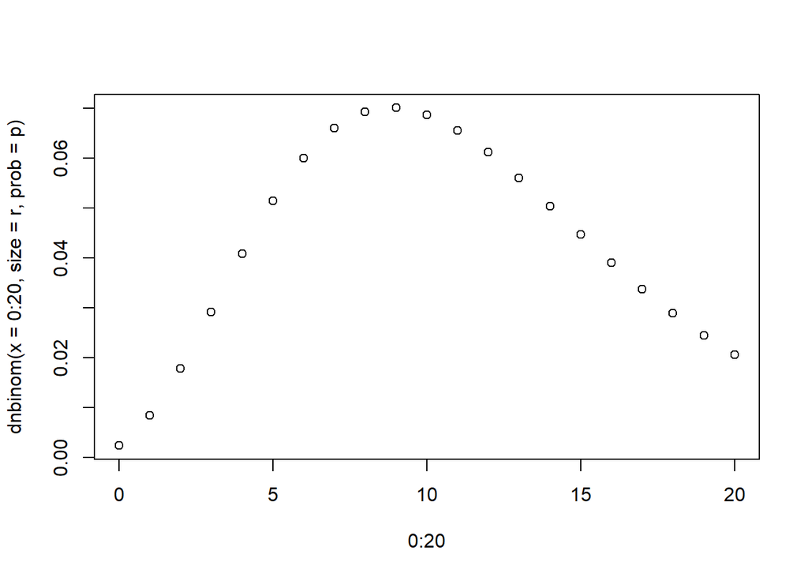

```r
plot(0:20,dnbinom(x=0:20,size=r,prob=p))
```